# 2.19

For the $2 \times 2$ case, we have

$$ \mathbf{A} = \left[ \begin{array}{cc} a & b \\ c & d \end{array} \right], \qquad \operatorname{Tr}(\mathbf{A}) =: T = a + d, \qquad \det(\mathbf{A}) =: D = ad-bc.$$

For $n \times n$ matrices, the trace is defined as the sum of the main diagonal entries.

The *trace-determinant plane* will be a convenient setting for us to classify all the types of phase plane behavior, as discussed in class.

In general, for an $n \times n$ matrix the trace will always be the sum of the eigenvalues (with repeats), and the determinant is always the product of the eigenvalues (with repeats). (However, note it's only the $2 \times 2$ case where we have this shortcut where the ENTIRE characteristic polynomial can be determined from the trace and dermininant.)

Here, we see

$$ \begin{align*} \det( \mathbf{A} - \lambda \mathbf{I}) = \left| \begin{array}{cc} a-\lambda & b \\ c & d-\lambda \end{array} \right| &= (a-\lambda)(d-\lambda) - bc \\ &= ad - a \lambda - d \lambda + \lambda^2 - bc\\ &= \lambda^2 - (a+d) \lambda + (ad-bc) \\ &= \lambda^2 - T\lambda + D. \end{align*} $$

Therefore, for $2 \times 2$ matrices we've verified the characteristic polynomial can be written

$$ \lambda^2 - T \lambda + D = 0.$$

We use this shortcut below:

# (i)

$$ \lambda^2 - (1+3)\lambda + 3(1)-(-2)(4) = \lambda^2 - 4 \lambda + 11 =0.$$

# (ii)

$$\lambda^2 - (1+4) \lambda + 1(4)-3(2) = \lambda^2 - 5 \lambda -2 = 0.$$

# (iii)

$$\lambda^2 - (3+0)\lambda + 3(0)-2(2) = \lambda^2 - 3 \lambda -4 = 0.$$

# 2.20

# (i)

We have

$$\mathbf{A} = \left[ \begin{array}{cc} 2 & 1 \\ 3 & 4 \end{array} \right]$$

and so using problem 2.19 we have the characteristic polynomial

$$\operatorname{tr}(\mathbf{A}) = 2 + 4 = 6, \qquad \det(\mathbf{A}) = 2(4)-3(1) = 5 \qquad \implies\qquad\lambda^2 - 6 \lambda + 5 = 0.$$

We have $(\lambda - 5)(\lambda - 1) = 0$ and so $\lambda = 5, 1$, meaning the origin is an unstable node for this system.

For $\lambda = 5$, we set up

$$ \left(\left[ \begin{array}{cc} 2 & 1 \\ 3 & 4 \end{array}\right] - 5\left[ \begin{array}{cc} 1 & 0 \\ 0 & 1 \end{array}\right] \right) \left[ \begin{array}{c}A \\ B\end{array}\right] = \left[ \begin{array}{c} 0 \\ 0 \end{array}\right],$$

or

$$ \left[ \begin{array}{cc} -3 & 1 \\ 3 & -1 \end{array} \right] \left[ \begin{array}{c}A \\ B\end{array}\right] = \left[ \begin{array}{c} 0 \\ 0 \end{array}\right].$$

We see $A=1, B=3$ works. Therefore, for $\lambda_1 = 5$ we have the associated eigenvector $\mathbf{v}_1 = [ 1, 3]^T$. (The superscript $T$ stands for "transpose" and emphasizes $\mathbf{v}_1$ is an $n \times 1$ "column vector" as opposed to a $1 \times n$ "row vector".

For $\lambda = 1$, we set up

$$ \left(\left[ \begin{array}{cc} 2 & 1 \\ 3 & 4 \end{array}\right] - 1 \left[ \begin{array}{cc} 1 & 0 \\ 0 & 1 \end{array}\right] \right) \left[ \begin{array}{c}A \\ B\end{array}\right] = \left[ \begin{array}{c} 0 \\ 0 \end{array}\right],$$

or

$$ \left[ \begin{array}{cc} 1 & 1 \\ 3 & 3 \end{array} \right] \left[ \begin{array}{c}A \\ B\end{array}\right] = \left[ \begin{array}{c} 0 \\ 0 \end{array}\right].$$

We see $A=1, B=-1$ works. Therfore, for $\lambda_2 = 1$ we have the associated eigenvector $\mathbf{v}_2 = [ 1, -1]^T$.

It is clear that both $\mathbf{x}_1(t) = e^{5t} \left[ \begin{array}{c} 1 \\ 3 \end{array} \right]$ and $\mathbf{x}_2(t) = e^{t} \left[ \begin{array}{c} 1 \\ -1 \end{array} \right]$ are solutions to the system $\mathbf{x}' = \mathbf{A} \mathbf{x}$ (standard derivative rules and eigenvalue-eigenvector property).

As the system is linear homogeneous,

$$ \mathbf{x}(t) = c_1 \mathbf{x}_1(t) + c_2 \mathbf{x}_2(t) = c_1 e^{5t} \left[ \begin{array}{c} 1 \\ 3 \end{array} \right] + c_2 e^{t} \left[ \begin{array}{c} 1 \\ -1 \end{array} \right]$$

is also a solution for any $c_1, c_2$. Since $W(t) \neq 0$ for all $t$ the functions $\mathbf{x}_1(t)$ and $\mathbf{x}_2(t)$ are linearly independent, and this must be the general solution.

(You don't have to check Wronskians unless I specifically ask you to, I only mentioned it here so you are aware of how we "know that these are ALL the solutions".)

Note that the eigenvectors (with directions $[1,3]^T$ and $[1,-1]^T$) correspond to straight line trajectories moving away from the origin.

As $t\to -\infty,$ we have $e^{5t}$ decays faster than $e^t$ and so "typical" trajectories approach the origin along the $[1,-1]^T$ direction as $t \to -\infty.$

As $t \to +\infty,$ the term with $e^{5t}$ grows faster than $e^t$and so the tangent vectors of the trajectories become increasingly parallel to $[1,3]^T$ as $t \to + \infty$.

Let's check our answer with sympy: (note that the answers may look different --- after relabeling / doing linear operations on arbitrary constants they are the same!) I've set up initial conditions along the eigenvectors so we can see the straight line trajectories, as well as some other initial conditions.

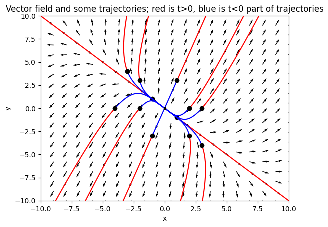

$\displaystyle \dfrac{d}{dt}\left[ \begin{array}{c} x(t) \\ y(t) \end{array} \right] = \left[ \begin{array}{cc} 2 & 1 \\ 3 & 4 \end{array} \right] \left[ \begin{array}{c} x(t) \\ y(t) \end{array} \right]$

```
General solution:
```

$\displaystyle x{\left(t \right)} = - C_{1} e^{t} + \frac{C_{2} e^{5 t}}{3}$

$\displaystyle y{\left(t \right)} = C_{1} e^{t} + C_{2} e^{5 t}$

```python
#@title 2.20(i) check:


from IPython.display import display, Math
import matplotlib.pyplot as plt
import numpy as np
from scipy.integrate import solve_ivp
from sympy import Function, dsolve, Eq, diff, symbols, latex, simplify, expand


#
# Define the matrix entries
#
a=2
b=1
c=3
d=4
#
# Enter the list of initial conditions to plot
#
ics = [[1,3],[1,-1],[-1,1],[-1,-3],[-2,3],[2,-3],[2,0],[-2,0], [-3,4], [3,-4], [3,0],[-4,0]]




# Define symbols for sympy
t = symbols('t')
x = Function('x')
y = Function('y')

def odesys(a,b,c,d):
  return [Eq (diff(x(t),t) , a*x(t) + b*y(t) ), Eq (diff(y(t),t) , c*x(t) + d*y(t) )]



# Define the ODE system for scipy to numerically integrate
def DE(t, z, a,b,c,d):
  x,y=z
  dx = a*x + b*y   #Here is where you input f(x,y) for the DE dx/dt = f(x,y)
  dy = c*x + d*y   #Here is where you input g(x,y) for the DE dy/dt = g(x,y)
  return [dx, dy]


# Define the solving/plotting function
def phase_plot(ics, tmax):
  plt.figure()
  # Define window from scale slider choice
  sc=10
  xmin = -sc
  xmax = sc
  ymin = -sc
  ymax = sc
  # Create a grid of points
  tgrid=np.linspace(0,tmax,1000)
  xgrid = np.linspace(xmin, xmax, 20)
  ygrid = np.linspace(ymin, ymax, 20)
  X, Y = np.meshgrid(xgrid, ygrid)
  # Calculate the vector field at each point, normalize to length 1
  U,V = DE(0,(X, Y), a,b,c,d)
  U,V = (U/np.sqrt(U**2+V**2), V/np.sqrt(U**2+V**2))
  #Solve numerically using solver from scipy
  for point in ics:
      [x_0, y_0] = point
      sol = solve_ivp(DE, (0,tmax), (x_0,y_0), args=(a,b,c,d), dense_output = 'true')
      sol2 = solve_ivp(DE, (0, -tmax), (x_0,y_0), args=(a,b,c,d), dense_output = 'true')
      xsol=sol.sol(tgrid)[0]
      ysol=sol.sol(tgrid)[1]
      plt.plot(xsol,ysol, color='red')
      xsol2=sol2.sol(-tgrid)[0]
      ysol2=sol2.sol(-tgrid)[1]
      plt.plot(xsol2,ysol2, color='blue')
      plt.plot(x_0, y_0, 'o', color='black')
  plt.plot(0,0,'.', color='black')
  #Plot slope field
  plt.quiver(X, Y, U, V,angles='xy')
  #Plot numerical solution satisfying x(0) = x_0, y(0) = y_0
  #Set up plot
  plt.xlabel('x')
  plt.ylabel('y')
  plt.xlim(xmin, xmax)
  plt.ylim(ymin, ymax)
  plt.title('Vector field and some trajectories; red is t>0, blue is t<0 part of trajectories')
  plt.show()
  display(Math(r'\dfrac{d}{dt}\left[ \begin{array}{c} x(t) \\ y(t) \end{array} \right] = \left[ \begin{array}{cc} %s & %s \\ %s & %s \end{array} \right] \left[ \begin{array}{c} x(t) \\ y(t) \end{array} \right]' % (a, b, c, d) ))
  print()
  print()
  print('General solution:')
  solution = dsolve(odesys(a,b,c,d))
  for comp in solution:
    display(Math(latex(expand(simplify(comp,rational=True)))))
    print()

phase_plot(ics, 10)
```

# (ii)

We have

$$\mathbf{A} = \left[ \begin{array}{cc} 2 & 2 \\ 2 & -1 \end{array} \right]$$

and so using problem 2.19 we have the characteristic polynomial

$$\operatorname{tr}(\mathbf{A}) = 2 + (-1) = 1, \qquad \det(\mathbf{A}) = 2(-1)-2(2) = -6 \qquad \implies\qquad\lambda^2 - \lambda -6 = 0.$$

We have $(\lambda -3)(\lambda +2) = 0$ and so $\lambda = 3, -2$, and so the origin is a saddle point for this system.

For $\lambda = 3$, we set up

$$ \left(\left[ \begin{array}{cc} 2 & 2 \\ 2 & -1 \end{array}\right] - 3\left[ \begin{array}{cc} 1 & 0 \\ 0 & 1 \end{array}\right] \right) \left[ \begin{array}{c}A \\ B\end{array}\right] = \left[ \begin{array}{c} 0 \\ 0 \end{array}\right],$$

or

$$ \left[ \begin{array}{cc} -1 & 2 \\ 2 & -4 \end{array} \right] \left[ \begin{array}{c}A \\ B\end{array}\right] = \left[ \begin{array}{c} 0 \\ 0 \end{array}\right].$$

We see $A=2, B=1$ works. Therefore, for $\lambda_1 = 3$ we have the associated eigenvector $\mathbf{v}_1 = [ 2, 1]^T$.

For $\lambda = -2$, we set up

$$ \left(\left[ \begin{array}{cc} 2 & 2 \\ 2 & -1 \end{array}\right] - (-2) \left[ \begin{array}{cc} 1 & 0 \\ 0 & 1 \end{array}\right] \right) \left[ \begin{array}{c}A \\ B\end{array}\right] = \left[ \begin{array}{c} 0 \\ 0 \end{array}\right],$$

or

$$ \left[ \begin{array}{cc} 4 & 2 \\ 2 & 1 \end{array} \right] \left[ \begin{array}{c}A \\ B\end{array}\right] = \left[ \begin{array}{c} 0 \\ 0 \end{array}\right].$$

We see $A=1, B=-2$ works. Therfore, for $\lambda_2 = -2$ we have the associated eigenvector $\mathbf{v}_2 = [ 1, -2]^T$.

It is clear that both $\mathbf{x}_1(t) = e^{3t} \left[ \begin{array}{c} 2 \\ 1 \end{array} \right]$ and $\mathbf{x}_2(t) = e^{-2t} \left[ \begin{array}{c} 1 \\ -2 \end{array} \right]$ are solutions to the system $\mathbf{x}' = \mathbf{A} \mathbf{x}$ (standard derivative rules and eigenvalue-eigenvector property).

As the system is linear homogeneous,

$$ \mathbf{x}(t) = c_1 \mathbf{x}_1(t) + c_2 \mathbf{x}_2(t) = c_1 e^{3t} \left[ \begin{array}{c} 2 \\ 1 \end{array} \right] + c_2 e^{-2t} \left[ \begin{array}{c} 1 \\ -2 \end{array} \right]$$

is also a solution for any $c_1, c_2$. Since $W(t) \neq 0$ for all $t$ the functions $\mathbf{x}_1(t)$ and $\mathbf{x}_2(t)$ are linearly independent, and this must be the general solution.

There are straight line trajectories along $[2,1]^T$ going away from the origin, and along $[1, -2]$ going towards the origin.

As $t \to +\infty,$ we see $e^{-2t} \to 0$ and so typical trajectories will approach the line through the origin with direction $[2,1]^T$.

As $t \to -\infty,$ we see $e^{3t} \to 0$ and so typical trajectories will approach the line through the origin with direction $[1,-2]^T$.

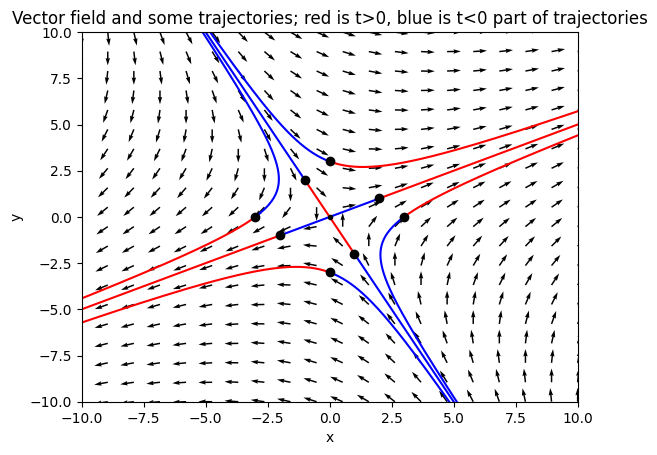

$\displaystyle \dfrac{d}{dt}\left[ \begin{array}{c} x(t) \\ y(t) \end{array} \right] = \left[ \begin{array}{cc} 2 & 2 \\ 2 & -1 \end{array} \right] \left[ \begin{array}{c} x(t) \\ y(t) \end{array} \right]$

```
General solution:
```

$\displaystyle x{\left(t \right)} = - \frac{C_{1} e^{- 2 t}}{2} + 2 C_{2} e^{3 t}$

$\displaystyle y{\left(t \right)} = C_{1} e^{- 2 t} + C_{2} e^{3 t}$

```python
#@title 2.20(ii) check:


from IPython.display import display, Math
import matplotlib.pyplot as plt
import numpy as np
from scipy.integrate import solve_ivp
from sympy import Function, dsolve, Eq, diff, symbols, latex, simplify, expand


#
# Define the matrix entries
#
a=2
b=2
c=2
d=-1
#
# Enter the list of initial conditions to plot
#
ics = [[1,-2],[2,1],[-1,2],[-2,-1],[0,3],[0,-3],[3,0],[-3,0]]




# Define symbols for sympy
t = symbols('t')
x = Function('x')
y = Function('y')

def odesys(a,b,c,d):
  return [Eq (diff(x(t),t) , a*x(t) + b*y(t) ), Eq (diff(y(t),t) , c*x(t) + d*y(t) )]



# Define the ODE system for scipy to numerically integrate
def DE(t, z, a,b,c,d):
  x,y=z
  dx = a*x + b*y   #Here is where you input f(x,y) for the DE dx/dt = f(x,y)
  dy = c*x + d*y   #Here is where you input g(x,y) for the DE dy/dt = g(x,y)
  return [dx, dy]


# Define the solving/plotting function
def phase_plot(ics, tmax):
  plt.figure()
  # Define window from scale slider choice
  sc=10
  xmin = -sc
  xmax = sc
  ymin = -sc
  ymax = sc
  # Create a grid of points
  tgrid=np.linspace(0,tmax,1000)
  xgrid = np.linspace(xmin, xmax, 20)
  ygrid = np.linspace(ymin, ymax, 20)
  X, Y = np.meshgrid(xgrid, ygrid)
  # Calculate the vector field at each point, normalize to length 1
  U,V = DE(0,(X, Y), a,b,c,d)
  U,V = (U/np.sqrt(U**2+V**2), V/np.sqrt(U**2+V**2))
  #Solve numerically using solver from scipy
  for point in ics:
      [x_0, y_0] = point
      sol = solve_ivp(DE, (0,tmax), (x_0,y_0), args=(a,b,c,d), dense_output = 'true')
      sol2 = solve_ivp(DE, (0, -tmax), (x_0,y_0), args=(a,b,c,d), dense_output = 'true')
      xsol=sol.sol(tgrid)[0]
      ysol=sol.sol(tgrid)[1]
      plt.plot(xsol,ysol, color='red')
      xsol2=sol2.sol(-tgrid)[0]
      ysol2=sol2.sol(-tgrid)[1]
      plt.plot(xsol2,ysol2, color='blue')
      plt.plot(x_0, y_0, 'o', color='black')
  plt.plot(0,0,'.', color='black')
  #Plot slope field
  plt.quiver(X, Y, U, V,angles='xy')
  #Plot numerical solution satisfying x(0) = x_0, y(0) = y_0
  #Set up plot
  plt.xlabel('x')
  plt.ylabel('y')
  plt.xlim(xmin, xmax)
  plt.ylim(ymin, ymax)
  plt.title('Vector field and some trajectories; red is t>0, blue is t<0 part of trajectories')
  plt.show()
  display(Math(r'\dfrac{d}{dt}\left[ \begin{array}{c} x(t) \\ y(t) \end{array} \right] = \left[ \begin{array}{cc} %s & %s \\ %s & %s \end{array} \right] \left[ \begin{array}{c} x(t) \\ y(t) \end{array} \right]' % (a, b, c, d) ))
  print()
  print()
  print('General solution:')
  solution = dsolve(odesys(a,b,c,d))
  for comp in solution:
    display(Math(latex(expand(simplify(comp,rational=True)))))
    print()

phase_plot(ics, 10)
```

# 2.21

We have

$$\mathbf{A} = \left[ \begin{array}{cc} 1 & 3 \\ 3 & 1 \end{array} \right]$$

and so using problem 2.19 we have the characteristic polynomial

$$\operatorname{tr}(\mathbf{A}) = 1+1=2, \qquad \det(\mathbf{A}) = 1(1)-3(3) = -8 \qquad \implies\qquad\lambda^2 - 2\lambda -8 = 0.$$

We have $(\lambda -4)(\lambda +2) = 0$ and so $\lambda = 4, -2$, and so the origin is a saddle point for this system.

For $\lambda = 4$, we set up

$$ \left(\left[ \begin{array}{cc} 1 & 3 \\ 3 & 1 \end{array}\right] - 4\left[ \begin{array}{cc} 1 & 0 \\ 0 & 1 \end{array}\right] \right) \left[ \begin{array}{c}A \\ B\end{array}\right] = \left[ \begin{array}{c} 0 \\ 0 \end{array}\right],$$

or

$$ \left[ \begin{array}{cc} -3 & 3 \\ 3 & -3 \end{array} \right] \left[ \begin{array}{c}A \\ B\end{array}\right] = \left[ \begin{array}{c} 0 \\ 0 \end{array}\right].$$

We see $A=1, B=1$ works. Therefore, for $\lambda_1 = 4$ we have the associated eigenvector $\mathbf{v}_1 = [ 1, 1]^T$.

For $\lambda = -2$, we set up

$$ \left(\left[ \begin{array}{cc} 1 & 3 \\ 3 & 1 \end{array}\right] - (-2) \left[ \begin{array}{cc} 1 & 0 \\ 0 & 1 \end{array}\right] \right) \left[ \begin{array}{c}A \\ B\end{array}\right] = \left[ \begin{array}{c} 0 \\ 0 \end{array}\right],$$

or

$$ \left[ \begin{array}{cc} 3 & 3 \\ 3 & 3 \end{array} \right] \left[ \begin{array}{c}A \\ B\end{array}\right] = \left[ \begin{array}{c} 0 \\ 0 \end{array}\right].$$

We see $A=1, B=-1$ works. Therfore, for $\lambda_2 = -2$ we have the associated eigenvector $\mathbf{v}_2 = [ 1, -1]^T$.

It is clear that both $\mathbf{x}_1(t) = e^{4t} \left[ \begin{array}{c} 1 \\ 1 \end{array} \right]$ and $\mathbf{x}_2(t) = e^{-2t} \left[ \begin{array}{c} 1 \\ -1 \end{array} \right]$ are solutions to the system $\mathbf{x}' = \mathbf{A} \mathbf{x}$ (standard derivative rules and eigenvalue-eigenvector property).

As the system is linear homogeneous,

$$ \mathbf{x}(t) = c_1 \mathbf{x}_1(t) + c_2 \mathbf{x}_2(t) = c_1 e^{4t} \left[ \begin{array}{c} 1 \\ 1 \end{array} \right] + c_2 e^{-2t} \left[ \begin{array}{c} 1 \\ -1 \end{array} \right]$$

is also a solution for any $c_1, c_2$. Since $W(t) \neq 0$ for all $t$ the functions $\mathbf{x}_1(t)$ and $\mathbf{x}_2(t)$ are linearly independent, and this must be the general solution.

Indeed, the initial condition $\mathbf{x}(0) = [-2, 1]^T$ (the extra $x$ in the book is a typo) is attained if

$$ \left[ \begin{array}{c} -2 \\ 1 \end{array} \right] = c_1 \left[ \begin{array}{c} 1 \\ 1 \end{array} \right] + c_2 \left[ \begin{array}{c} 1 \\ -1 \end{array} \right] = \left[ \begin{array}{c} c_1 + c_2 \\ c_1 - c_2 \end{array} \right] = \left[ \begin{array}{cc} 1 & 1 \\ 1 & -1 \end{array} \right]\left[ \begin{array}{c} c_1 \\ c_2 \end{array} \right] .$$

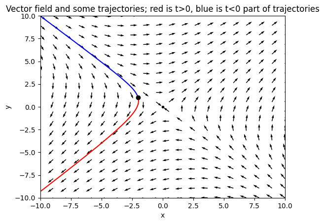

$\displaystyle \dfrac{d}{dt}\left[ \begin{array}{c} x(t) \\ y(t) \end{array} \right] = \left[ \begin{array}{cc} 1 & 3 \\ 3 & 1 \end{array} \right] \left[ \begin{array}{c} x(t) \\ y(t) \end{array} \right]$

```
General solution:
```

$\displaystyle x{\left(t \right)} = - \frac{e^{4 t}}{2} - \frac{3 e^{- 2 t}}{2}$

$\displaystyle y{\left(t \right)} = - \frac{e^{4 t}}{2} + \frac{3 e^{- 2 t}}{2}$

```python
#@title 2.21 check:


from IPython.display import display, Math
import matplotlib.pyplot as plt
import numpy as np
from scipy.integrate import solve_ivp
from sympy import Function, dsolve, Eq, diff, symbols, latex, simplify, expand


#
# Define the matrix entries
#
a=1
b=3
c=3
d=1
#
# Enter the list of initial conditions to plot
#
ics = [[-2,1]]




# Define symbols for sympy
t = symbols('t')
x = Function('x')
y = Function('y')

def odesys(a,b,c,d):
  return [Eq (diff(x(t),t) , a*x(t) + b*y(t) ), Eq (diff(y(t),t) , c*x(t) + d*y(t) )]



# Define the ODE system for scipy to numerically integrate
def DE(t, z, a,b,c,d):
  x,y=z
  dx = a*x + b*y   #Here is where you input f(x,y) for the DE dx/dt = f(x,y)
  dy = c*x + d*y   #Here is where you input g(x,y) for the DE dy/dt = g(x,y)
  return [dx, dy]


# Define the solving/plotting function
def phase_plot(ics, tmax):
  plt.figure()
  # Define window from scale slider choice
  sc=10
  xmin = -sc
  xmax = sc
  ymin = -sc
  ymax = sc
  # Create a grid of points
  tgrid=np.linspace(0,tmax,1000)
  xgrid = np.linspace(xmin, xmax, 20)
  ygrid = np.linspace(ymin, ymax, 20)
  X, Y = np.meshgrid(xgrid, ygrid)
  # Calculate the vector field at each point, normalize to length 1
  U,V = DE(0,(X, Y), a,b,c,d)
  U,V = (U/np.sqrt(U**2+V**2), V/np.sqrt(U**2+V**2))

  #Solve numerically using solver from scipy
  for point in ics:
      [x_0, y_0] = point
      sol = solve_ivp(DE, (0,tmax), (x_0,y_0), args=(a,b,c,d), dense_output = 'true')
      sol2 = solve_ivp(DE, (0, -tmax), (x_0,y_0), args=(a,b,c,d), dense_output = 'true')
      xsol=sol.sol(tgrid)[0]
      ysol=sol.sol(tgrid)[1]
      plt.plot(xsol,ysol, color='red')
      xsol2=sol2.sol(-tgrid)[0]
      ysol2=sol2.sol(-tgrid)[1]
      plt.plot(xsol2,ysol2, color='blue')
      plt.plot(x_0, y_0, 'o', color='black')
  plt.plot(0,0,'.', color='black')
  #Plot slope field
  plt.quiver(X, Y, U, V,angles='xy')
  #Plot numerical solution satisfying x(0) = x_0, y(0) = y_0
  #Set up plot
  plt.xlabel('x')
  plt.ylabel('y')
  plt.xlim(xmin, xmax)
  plt.ylim(ymin, ymax)
  plt.title('Vector field and some trajectories; red is t>0, blue is t<0 part of trajectories')
  plt.show()
  display(Math(r'\dfrac{d}{dt}\left[ \begin{array}{c} x(t) \\ y(t) \end{array} \right] = \left[ \begin{array}{cc} %s & %s \\ %s & %s \end{array} \right] \left[ \begin{array}{c} x(t) \\ y(t) \end{array} \right]' % (a, b, c, d) ))
  print()
  print()
  print('General solution:')
  initial_conditions = { x(0):-2 , y(0):1 }
  solution = dsolve(odesys(a,b,c,d), ics=initial_conditions)
  for comp in solution:
    display(Math(latex(expand(simplify(comp,rational=True)))))
    print()

phase_plot(ics, 10)
```

# 2.23

# (i)

We have

$$\mathbf{A} = \left[ \begin{array}{cc} 0 & 9 \\ -9 & 0 \end{array} \right]$$

and so using problem 2.19 we have the characteristic polynomial

$$\operatorname{tr}(\mathbf{A}) = 0 + 0 = 0, \qquad \det(\mathbf{A}) = 0(0)-9(-9) = 81 \qquad \implies\qquad\lambda^2 +81 = 0.$$

We have purely imaginary roots $\lambda_{1,2} = 0 \pm 9i$, and so the origin is a center for this system. We choose $\lambda = 9i$ and seek a complex eigenvector $\mathbf{v}$, after which we'll take a linear combination of the real and imaginary parts of $e^{\lambda t} \mathbf{v}$, using Euler's formula to deal with the complex exponential.

For $\lambda = 9i$, we set up

$$ \left(\left[ \begin{array}{cc} 0 & 9\\ -9 & 0 \end{array}\right] - 9i \left[ \begin{array}{cc} 1 & 0 \\ 0 & 1 \end{array}\right] \right) \left[ \begin{array}{c}A \\ B\end{array}\right] = \left[ \begin{array}{c} 0 \\ 0 \end{array}\right],$$

or

$$ \left[ \begin{array}{cc} -9i & 9 \\ -9 & -9i \end{array} \right] \left[ \begin{array}{c}A \\ B\end{array}\right] = \left[ \begin{array}{c} 0 \\ 0 \end{array}\right].$$

We see $A=1, B=i$ works. Therefore, for $\lambda = 9i$ we have the associated eigenvector $\mathbf{v}_1 = [ 1, i]^T$.

Using something like Exercise 19.7, it can be shown that since $e^{9i t}[ 1, i]^T$ solves the ODE system (the coefficients are real), that both $\operatorname{Re}\left(e^{9i t}[ 1, i]^T\right)$ and $\operatorname{Im}\left(e^{9i t}[ 1, i]^T\right)$ separately solve the same system. These turn out to be linearly independent, and since we only need two independent solutions for the general solution of this $2 \times 2$ we don't have to worry about the conjugate eigenvalue at all.

We have

$$ e^{\lambda t} \mathbf{v} = e^{9i t} \left[ \begin{array}{c} 1 \\ i \end{array} \right] = (\cos 9t + i \sin 9t)\left[ \begin{array}{c} 1 \\ i \end{array} \right] = \left[ \begin{array}{c} \cos 9t + i \sin 9t \\ i \cos 9t + i^2 \sin 9t \end{array} \right] = \left[ \begin{array}{c} \cos 9t \\ - \sin 9t \end{array} \right] + i \left[ \begin{array}{c} \sin 9t \\ \cos 9t \end{array} \right] .$$

Therefore, the general solution is

$$\mathbf{x}(t) = c_1 \operatorname{Re}(e^{\lambda t} \mathbf{v})+c_2 \operatorname{Im}(e^{\lambda t} \mathbf{v}) = c_1 \left[ \begin{array}{c} \cos 9t \\ - \sin 9t \end{array} \right] + c_2 \left[ \begin{array}{c} \sin 9t \\ \cos 9t \end{array} \right] .$$

Evaluating the vector field $\mathbf{A} \mathbf{x}$ at say $\mathbf{x} = [1,0]^T$ yields $[0, -9]^T$, and so the trajectories go around the origin clockwise.

Let's check our answer with sympy:

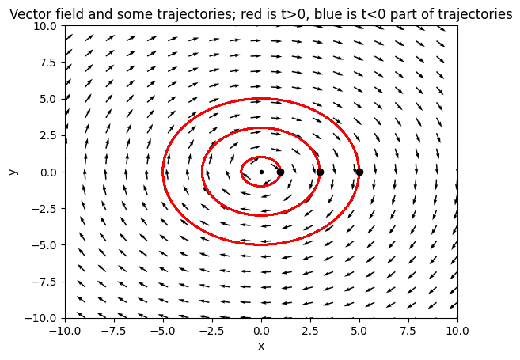

$\displaystyle \dfrac{d}{dt}\left[ \begin{array}{c} x(t) \\ y(t) \end{array} \right] = \left[ \begin{array}{cc} 0 & 9 \\ -9 & 0 \end{array} \right] \left[ \begin{array}{c} x(t) \\ y(t) \end{array} \right]$

```
General solution:
```

$\displaystyle x{\left(t \right)} = C_{1} \sin{\left(9 t \right)} + C_{2} \cos{\left(9 t \right)}$

$\displaystyle y{\left(t \right)} = C_{1} \cos{\left(9 t \right)} - C_{2} \sin{\left(9 t \right)}$

```python
#@title 2.23(i) check:


from IPython.display import display, Math
import matplotlib.pyplot as plt
import numpy as np
from scipy.integrate import solve_ivp
from sympy import Function, dsolve, Eq, diff, symbols, latex, simplify, expand


#
# Define the matrix entries
#
a=0
b=9
c=-9
d=0
#
# Enter the list of initial conditions to plot
#
ics = [[1,0], [3,0], [5,0]]




# Define symbols for sympy
t = symbols('t')
x = Function('x')
y = Function('y')

def odesys(a,b,c,d):
  return [Eq (diff(x(t),t) , a*x(t) + b*y(t) ), Eq (diff(y(t),t) , c*x(t) + d*y(t) )]



# Define the ODE system for scipy to numerically integrate
def DE(t, z, a,b,c,d):
  x,y=z
  dx = a*x + b*y   #Here is where you input f(x,y) for the DE dx/dt = f(x,y)
  dy = c*x + d*y   #Here is where you input g(x,y) for the DE dy/dt = g(x,y)
  return [dx, dy]


# Define the solving/plotting function
def phase_plot(ics, tmax):
  plt.figure()
  # Define window from scale slider choice
  sc=10
  xmin = -sc
  xmax = sc
  ymin = -sc
  ymax = sc
  # Create a grid of points
  tgrid=np.linspace(0,tmax,1000)
  xgrid = np.linspace(xmin, xmax, 20)
  ygrid = np.linspace(ymin, ymax, 20)
  X, Y = np.meshgrid(xgrid, ygrid)
  # Calculate the vector field at each point, normalize to length 1
  U,V = DE(0,(X, Y), a,b,c,d)
  U,V = (U/np.sqrt(U**2+V**2), V/np.sqrt(U**2+V**2))

  #Solve numerically using solver from scipy
  for point in ics:
      [x_0, y_0] = point
      sol = solve_ivp(DE, (0,tmax), (x_0,y_0), args=(a,b,c,d), dense_output = 'true')
      sol2 = solve_ivp(DE, (0, -tmax), (x_0,y_0), args=(a,b,c,d), dense_output = 'true')
      xsol2=sol2.sol(-tgrid)[0]
      ysol2=sol2.sol(-tgrid)[1]
      plt.plot(xsol2,ysol2, color='blue')
      xsol=sol.sol(tgrid)[0]
      ysol=sol.sol(tgrid)[1]
      plt.plot(xsol,ysol, color='red')
      plt.plot(x_0, y_0, 'o', color='black')
  plt.plot(0,0,'.', color='black')
  #Plot slope field
  plt.quiver(X, Y, U, V,angles='xy')
  #Plot numerical solution satisfying x(0) = x_0, y(0) = y_0
  #Set up plot
  plt.xlabel('x')
  plt.ylabel('y')
  plt.xlim(xmin, xmax)
  plt.ylim(ymin, ymax)
  plt.title('Vector field and some trajectories; red is t>0, blue is t<0 part of trajectories')
  plt.show()
  display(Math(r'\dfrac{d}{dt}\left[ \begin{array}{c} x(t) \\ y(t) \end{array} \right] = \left[ \begin{array}{cc} %s & %s \\ %s & %s \end{array} \right] \left[ \begin{array}{c} x(t) \\ y(t) \end{array} \right]' % (a, b, c, d) ))
  print()
  print()
  print('General solution:')
  solution = dsolve(odesys(a,b,c,d))
  for comp in solution:
    display(Math(latex(expand(simplify(comp,rational=True)))))
    print()

phase_plot(ics, 10)
```

# (ii)

We have

$$\mathbf{A} = \left[ \begin{array}{cc} 1 & 1 \\ -1 & 1 \end{array} \right].$$

We have the characteristic polynomial

$$(1-\lambda)(1-\lambda) - (-1)(1) = (1-\lambda^2) + 1 = 0,$$

which has complex roots $1- \lambda = \pm 1$ and so $\lambda_{1,2} = 1 \pm i,$ and so the origin is an unstable spiral for this system.

We choose $\lambda = 1+i$ and seek a complex eigenvector $\mathbf{v}$, after which we'll take a linear combination of the real and imaginary parts of $e^{\lambda t} \mathbf{v}$, using Euler's formula to deal with the complex exponential.

For $\lambda = 1+i$, we set up

$$ \left(\left[ \begin{array}{cc} 1 & 1\\ -1 & 1 \end{array}\right] - (1+i) \left[ \begin{array}{cc} 1 & 0 \\ 0 & 1 \end{array}\right] \right) \left[ \begin{array}{c}A \\ B\end{array}\right] = \left[ \begin{array}{c} 0 \\ 0 \end{array}\right],$$

or

$$ \left[ \begin{array}{cc} -i & 1 \\ -1 & -i \end{array} \right] \left[ \begin{array}{c}A \\ B\end{array}\right] = \left[ \begin{array}{c} 0 \\ 0 \end{array}\right].$$

We see $A=1, B=i$ works. Therefore, for $\lambda = 1+i$ we have the associated eigenvector $\mathbf{v}_1 = [ 1, i]^T$.

Using something like Exercise 19.7, it can be shown that since $e^{(1+i) t}[ 1, i]^T$ solves the ODE system (the coefficients are real), that both $\operatorname{Re}\left(e^{(1+i) t}[ 1, i]^T\right)$ and $\operatorname{Im}\left(e^{(1+i) t}[ 1, i]^T\right)$ separately solve the same system. These turn out to be linearly independent, and since we only need two independent solutions for the general solution of this $2 \times 2$ we don't have to worry about the conjugate eigenvalue at all.

We have

$$ e^{\lambda t} \mathbf{v} = e^{(1+i) t} \left[ \begin{array}{c} 1 \\ i \end{array} \right] = e^te^{it} \left[ \begin{array}{c} 1 \\ i \end{array} \right] = e^t (\cos t + i \sin t) \left[ \begin{array}{c} 1 \\ i \end{array} \right] = e^t \left[ \begin{array}{c} \cos t + i \sin t \\ i \cos t + i^2 \sin t \end{array} \right] = e^t \left[ \begin{array}{c} \cos t \\ - \sin t \end{array} \right] + i \left[ \begin{array}{c} \sin t \\ \cos t \end{array} \right] .$$

Therefore, the general solution is

$$\mathbf{x}(t) = c_1 \operatorname{Re}(e^{\lambda t} \mathbf{v})+c_2 \operatorname{Im}(e^{\lambda t} \mathbf{v}) = c_1 e^t \left[ \begin{array}{c} \cos t \\ - \sin t \end{array} \right] + c_2 e^t \left[ \begin{array}{c} \sin t \\ \cos t \end{array} \right] .$$

Evaluating the vector field $\mathbf{A} \mathbf{x}$ at say $\mathbf{x} = [1,0]^T$ yields $[1,-1]^T$, and so the trajectories go around the origin clockwise.

Let's use sympy to check our answer: (note that our solutions may look different, but are equivalent up to renaming/ taking linear combinations of arbitrary constants)

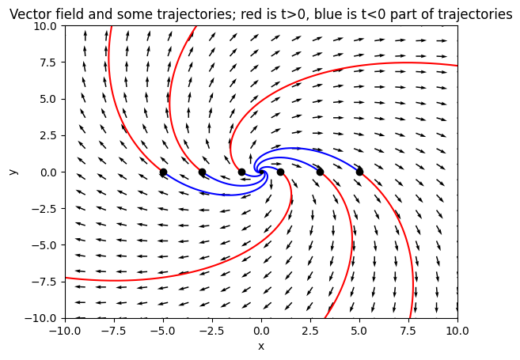

$\displaystyle \dfrac{d}{dt}\left[ \begin{array}{c} x(t) \\ y(t) \end{array} \right] = \left[ \begin{array}{cc} 1 & 1 \\ -1 & 1 \end{array} \right] \left[ \begin{array}{c} x(t) \\ y(t) \end{array} \right]$

```
General solution:
```

$\displaystyle x{\left(t \right)} = C_{1} e^{t} \sin{\left(t \right)} + C_{2} e^{t} \cos{\left(t \right)}$

$\displaystyle y{\left(t \right)} = C_{1} e^{t} \cos{\left(t \right)} - C_{2} e^{t} \sin{\left(t \right)}$

```python
#@title 2.23(ii) check:


from IPython.display import display, Math
import matplotlib.pyplot as plt
import numpy as np
from scipy.integrate import solve_ivp
from sympy import Function, dsolve, Eq, diff, symbols, latex, simplify, expand


#
# Define the matrix entries
#
a=1
b=1
c=-1
d=1
#
# Enter the list of initial conditions to plot
#
ics = [[1,0], [3,0], [5,0], [-1,0],[-3,0],[-5,0]]




# Define symbols for sympy
t = symbols('t')
x = Function('x')
y = Function('y')

def odesys(a,b,c,d):
  return [Eq (diff(x(t),t) , a*x(t) + b*y(t) ), Eq (diff(y(t),t) , c*x(t) + d*y(t) )]



# Define the ODE system for scipy to numerically integrate
def DE(t, z, a,b,c,d):
  x,y=z
  dx = a*x + b*y   #Here is where you input f(x,y) for the DE dx/dt = f(x,y)
  dy = c*x + d*y   #Here is where you input g(x,y) for the DE dy/dt = g(x,y)
  return [dx, dy]


# Define the solving/plotting function
def phase_plot(ics, tmax):
  plt.figure()
  # Define window from scale slider choice
  sc=10
  xmin = -sc
  xmax = sc
  ymin = -sc
  ymax = sc
  # Create a grid of points
  tgrid=np.linspace(0,tmax,1000)
  xgrid = np.linspace(xmin, xmax, 20)
  ygrid = np.linspace(ymin, ymax, 20)
  X, Y = np.meshgrid(xgrid, ygrid)
  # Calculate the vector field at each point, normalize to length 1
  U,V = DE(0,(X, Y), a,b,c,d)
  U,V = (U/np.sqrt(U**2+V**2), V/np.sqrt(U**2+V**2))

  #Solve numerically using solver from scipy
  for point in ics:
      [x_0, y_0] = point
      sol = solve_ivp(DE, (0,tmax), (x_0,y_0), args=(a,b,c,d), dense_output = 'true')
      sol2 = solve_ivp(DE, (0, -tmax), (x_0,y_0), args=(a,b,c,d), dense_output = 'true')
      xsol=sol.sol(tgrid)[0]
      ysol=sol.sol(tgrid)[1]
      plt.plot(xsol,ysol, color='red')
      xsol2=sol2.sol(-tgrid)[0]
      ysol2=sol2.sol(-tgrid)[1]
      plt.plot(xsol2,ysol2, color='blue')
      plt.plot(x_0, y_0, 'o', color='black')
  plt.plot(0,0,'.', color='black')
  #Plot slope field
  plt.quiver(X, Y, U, V,angles='xy')
  #Plot numerical solution satisfying x(0) = x_0, y(0) = y_0
  #Set up plot
  plt.xlabel('x')
  plt.ylabel('y')
  plt.xlim(xmin, xmax)
  plt.ylim(ymin, ymax)
  plt.title('Vector field and some trajectories; red is t>0, blue is t<0 part of trajectories')
  plt.show()
  display(Math(r'\dfrac{d}{dt}\left[ \begin{array}{c} x(t) \\ y(t) \end{array} \right] = \left[ \begin{array}{cc} %s & %s \\ %s & %s \end{array} \right] \left[ \begin{array}{c} x(t) \\ y(t) \end{array} \right]' % (a, b, c, d) ))
  print()
  print()
  print('General solution:')
  solution = dsolve(odesys(a,b,c,d))
  for comp in solution:
    display(Math(latex(expand(simplify(comp,rational=True)))))
    print()

phase_plot(ics, 10)
```

# 3.9

# (i)

For $$\mathbf{A} = \left[ \begin{array}{cc} -5 & -1 \\ 6 & 0 \end{array} \right], $$ we have $$0 = \lambda^2 - \operatorname{tr}(\mathbf{A})\lambda + \operatorname{det}(\mathbf{A}) = \lambda^2 - (-5)\lambda + 6 = (\lambda+2)(\lambda+3).$$

Since $\lambda = -2, -3$ are negative and real, the origin is a $\boxed{\text{stable node}}$ for this system.

Then, for $\lambda_1 = -2$ we set up

$$ (\mathbf{A}-(-2) \mathbf{I})\mathbf{v}_1 = \mathbf{0} = \left[ \begin{array}{cc} -3 & -1 \\ 6 & 2 \end{array} \right] \mathbf{v}_1 = \mathbf{0},$$

and so $\mathbf{v}_1 = [ 1, -3]^T$ works.

For $\lambda_2 = -3$ we set up

$$ (\mathbf{A}-(-3) \mathbf{I})\mathbf{v}_2 = \mathbf{0} = \left[ \begin{array}{cc} -2 & -1 \\ 6 & 3 \end{array} \right] \mathbf{v}_2 = \mathbf{0},$$

and so $\mathbf{v}_2 = [ 1, -2]^T$ works. Putting it together, the general solution is

$$\mathbf{x}(t) = c_1 e^{\lambda_1 t} \mathbf{v}_1+c_2 e^{\lambda_2 t} \mathbf{v}_2 = c_1 e^{-2t} \left[ \begin{array}{c} 1 \\ -3 \end{array} \right] + c_2 e^{-3t} \left[ \begin{array}{c} 1 \\ -2 \end{array} \right].$$

If $c_2 = 0$ we have straight line trajectories along the $\mathbf{v}_1$ direction that approach the origin (since $\lambda_1 < 0$), while if $c_1 = 0$ we have straight line trajectories along the $\mathbf{v}_2$ direction that approach the origin (since $\lambda_2 < 0$).

As $t \to \infty$, the term from $\lambda_2 = -3$ decays faster, and so "typical" trajectories will approach the origin along the $\mathbf{v}_1 = [1,-3]^T$ direction.

As $t \to -\infty$, the term from $\lambda_1 = -2$ doesn't grow as fast, and so "typical" trajectories will "become approximately parallel to $\mathbf{v}_2 = [1,-2]^T$ as we "rewind" $t\to -\infty$ to "go backwards" along the trajectories.

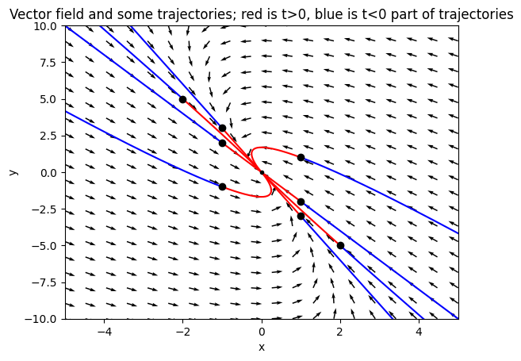

$\displaystyle \dfrac{d}{dt}\left[ \begin{array}{c} x(t) \\ y(t) \end{array} \right] = \left[ \begin{array}{cc} -5 & -1 \\ 6 & 0 \end{array} \right] \left[ \begin{array}{c} x(t) \\ y(t) \end{array} \right]$

```
General solution:
```

$\displaystyle x{\left(t \right)} = - \frac{C_{1} e^{- 3 t}}{2} - \frac{C_{2} e^{- 2 t}}{3}$

$\displaystyle y{\left(t \right)} = C_{1} e^{- 3 t} + C_{2} e^{- 2 t}$

```python
#@title 3.9(i)


from IPython.display import display, Math
import matplotlib.pyplot as plt
import numpy as np
from scipy.integrate import solve_ivp
from sympy import Function, dsolve, Eq, diff, symbols, latex, simplify, expand


#
# Define the matrix entries
#
a=-5
b=-1
c=6
d=0
#
# Enter the list of initial conditions to plot
#
ics = [[1,1], [2,-5],[-1, -1],[-2, 5], [1, -2], [1, -3], [-1, 2], [-1, 3]]




# Define symbols for sympy
t = symbols('t')
x = Function('x')
y = Function('y')

def odesys(a,b,c,d):
  return [Eq (diff(x(t),t) , a*x(t) + b*y(t) ), Eq (diff(y(t),t) , c*x(t) + d*y(t) )]



# Define the ODE system for scipy to numerically integrate
def DE(t, z, a,b,c,d):
  x,y=z
  dx = a*x + b*y   #Here is where you input f(x,y) for the DE dx/dt = f(x,y)
  dy = c*x + d*y   #Here is where you input g(x,y) for the DE dy/dt = g(x,y)
  return [dx, dy]


# Define the solving/plotting function
def phase_plot(ics, tmax):
  plt.figure()
  # Define window from scale slider choice
  sc=10
  xmin = -sc/2
  xmax = sc/2
  ymin = -sc
  ymax = sc
  # Create a grid of points
  tgrid=np.linspace(0,tmax,1000)
  xgrid = np.linspace(xmin, xmax, 20)
  ygrid = np.linspace(ymin, ymax, 20)
  X, Y = np.meshgrid(xgrid, ygrid)
  # Calculate the vector field at each point, normalize to length 1
  U,V = DE(0,(X, Y), a,b,c,d)
  U,V = (U/np.sqrt(U**2+V**2), V/np.sqrt(U**2+V**2))

  #Solve numerically using solver from scipy
  for point in ics:
      [x_0, y_0] = point
      sol = solve_ivp(DE, (0,tmax), (x_0,y_0), args=(a,b,c,d), dense_output = 'true')
      sol2 = solve_ivp(DE, (0, -tmax), (x_0,y_0), args=(a,b,c,d), dense_output = 'true')
      xsol=sol.sol(tgrid)[0]
      ysol=sol.sol(tgrid)[1]
      plt.plot(xsol,ysol, color='red')
      xsol2=sol2.sol(-tgrid)[0]
      ysol2=sol2.sol(-tgrid)[1]
      plt.plot(xsol2,ysol2, color='blue')
      plt.plot(x_0, y_0, 'o', color='black')
  plt.plot(0,0,'.', color='black')
  #Plot slope field
  plt.quiver(X, Y, U, V,angles='xy')
  #Plot numerical solution satisfying x(0) = x_0, y(0) = y_0
  #Set up plot
  plt.xlabel('x')
  plt.ylabel('y')
  plt.xlim(xmin, xmax)
  plt.ylim(ymin, ymax)
  plt.title('Vector field and some trajectories; red is t>0, blue is t<0 part of trajectories')
  plt.show()
  display(Math(r'\dfrac{d}{dt}\left[ \begin{array}{c} x(t) \\ y(t) \end{array} \right] = \left[ \begin{array}{cc} %s & %s \\ %s & %s \end{array} \right] \left[ \begin{array}{c} x(t) \\ y(t) \end{array} \right]' % (a, b, c, d) ))
  print()
  print()
  print('General solution:')
  solution = dsolve(odesys(a,b,c,d))
  for comp in solution:
    display(Math(latex(expand(simplify(comp,rational=True)))))
    print()

phase_plot(ics, 10)
```

# (ii)

For $$\mathbf{A} = \left[ \begin{array}{cc} 1 & 0 \\ 2 & -2 \end{array} \right], $$ we have $$0 = \lambda^2 - \operatorname{tr}(\mathbf{A})\lambda + \operatorname{det}(\mathbf{A}) = \lambda^2 - (-1)\lambda + (-2) = \lambda^2 + \lambda - 2= (\lambda+2)(\lambda-1).$$

Since $\lambda = -2, 1$ are real with opposite sign, the origin is an $\boxed{\text{(unstable) saddle}}$ for the system.

Then, for $\lambda_1 = -2$ we set up

$$ (\mathbf{A}-(-2) \mathbf{I})\mathbf{v}_1 = \mathbf{0} = \left[ \begin{array}{cc} 3 & 0 \\ 2 & 0 \end{array} \right] \mathbf{v}_1 = \mathbf{0},$$

and so $\mathbf{v}_1 = [ 0,1]^T$ works.

For $\lambda_2 = 1$ we set up

$$ (\mathbf{A}-(1) \mathbf{I})\mathbf{v}_2 = \mathbf{0} = \left[ \begin{array}{cc} 0 & 0 \\ 2 & -3 \end{array} \right] \mathbf{v}_2 = \mathbf{0},$$

and so $\mathbf{v}_2 = [ 3, 2]^T$ works. Putting it together, the general solution is

$$\mathbf{x}(t) = c_1 e^{\lambda_1 t} \mathbf{v}_1+c_2 e^{\lambda_2 t} \mathbf{v}_2 = c_1 e^{-2t} \left[ \begin{array}{c} 0 \\ 1 \end{array} \right] + c_2 e^{t} \left[ \begin{array}{c} 3 \\ 2 \end{array} \right].$$

If $c_2 = 0$ we have straight line trajectories along the $\mathbf{v}_1$ direction that approach the origin (since $\lambda_1 < 0$), while if $c_1 = 0$ we have straight line trajectories along the $\mathbf{v}_2$ direction go away from the origin (since $\lambda_2 > 0$).

As $t \to \infty$, the term from $\lambda_1 = -2$ decays, and so "typical" trajectories "veer past" the saddle and point along the $\mathbf{v}_2 = [3,2]^T$ direction as $t \to \infty$.

As $t \to -\infty$, the term from $\lambda_2 = 1$ decays, and so "typical" trajectories will "become approximately along the $\mathbf{v}_1=[0,1]^T$ direction as we "rewind" $t\to -\infty$ to "go backwards" along the trajectories.

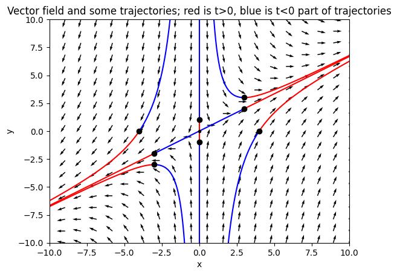

$\displaystyle \dfrac{d}{dt}\left[ \begin{array}{c} x(t) \\ y(t) \end{array} \right] = \left[ \begin{array}{cc} 1 & 0 \\ 2 & -2 \end{array} \right] \left[ \begin{array}{c} x(t) \\ y(t) \end{array} \right]$

```
General solution:
```

$\displaystyle x{\left(t \right)} = \frac{3 C_{1} e^{t}}{2}$

$\displaystyle y{\left(t \right)} = C_{1} e^{t} + C_{2} e^{- 2 t}$

```python
#@title 3.9(ii)


from IPython.display import display, Math
import matplotlib.pyplot as plt
import numpy as np
from scipy.integrate import solve_ivp
from sympy import Function, dsolve, Eq, diff, symbols, latex, simplify, expand


#
# Define the matrix entries
#
a=1
b=0
c=2
d=-2
#
# Enter the list of initial conditions to plot
#
ics = [[3,3], [0, 1],[-3, -3],[0, -1], [4, 0], [-4, 0], [3, 2], [-3, -2]]




# Define symbols for sympy
t = symbols('t')
x = Function('x')
y = Function('y')

def odesys(a,b,c,d):
  return [Eq (diff(x(t),t) , a*x(t) + b*y(t) ), Eq (diff(y(t),t) , c*x(t) + d*y(t) )]



# Define the ODE system for scipy to numerically integrate
def DE(t, z, a,b,c,d):
  x,y=z
  dx = a*x + b*y   #Here is where you input f(x,y) for the DE dx/dt = f(x,y)
  dy = c*x + d*y   #Here is where you input g(x,y) for the DE dy/dt = g(x,y)
  return [dx, dy]


# Define the solving/plotting function
def phase_plot(ics, tmax):
  plt.figure()
  # Define window from scale slider choice
  sc=10
  xmin = -sc
  xmax = sc
  ymin = -sc
  ymax = sc
  # Create a grid of points
  tgrid=np.linspace(0,tmax,1000)
  xgrid = np.linspace(xmin, xmax, 20)
  ygrid = np.linspace(ymin, ymax, 20)
  X, Y = np.meshgrid(xgrid, ygrid)
  # Calculate the vector field at each point, normalize to length 1
  U,V = DE(0,(X, Y), a,b,c,d)
  U,V = (U/np.sqrt(U**2+V**2), V/np.sqrt(U**2+V**2))

  #Solve numerically using solver from scipy
  for point in ics:
      [x_0, y_0] = point
      sol = solve_ivp(DE, (0,tmax), (x_0,y_0), args=(a,b,c,d), dense_output = 'true')
      sol2 = solve_ivp(DE, (0, -tmax), (x_0,y_0), args=(a,b,c,d), dense_output = 'true')
      xsol=sol.sol(tgrid)[0]
      ysol=sol.sol(tgrid)[1]
      plt.plot(xsol,ysol, color='red')
      xsol2=sol2.sol(-tgrid)[0]
      ysol2=sol2.sol(-tgrid)[1]
      plt.plot(xsol2,ysol2, color='blue')
      plt.plot(x_0, y_0, 'o', color='black')
  plt.plot(0,0,'.', color='black')
  #Plot slope field
  plt.quiver(X, Y, U, V,angles='xy')
  #Plot numerical solution satisfying x(0) = x_0, y(0) = y_0
  #Set up plot
  plt.xlabel('x')
  plt.ylabel('y')
  plt.xlim(xmin, xmax)
  plt.ylim(ymin, ymax)
  plt.title('Vector field and some trajectories; red is t>0, blue is t<0 part of trajectories')
  plt.show()
  display(Math(r'\dfrac{d}{dt}\left[ \begin{array}{c} x(t) \\ y(t) \end{array} \right] = \left[ \begin{array}{cc} %s & %s \\ %s & %s \end{array} \right] \left[ \begin{array}{c} x(t) \\ y(t) \end{array} \right]' % (a, b, c, d) ))
  print()
  print()
  print('General solution:')
  solution = dsolve(odesys(a,b,c,d))
  for comp in solution:
    display(Math(latex(expand(simplify(comp,rational=True)))))
    print()

phase_plot(ics, 10)
```

# 3.12

# (i)

For $$\mathbf{A} = \left[ \begin{array}{cc} 0 & 4 \\ -4 & 0 \end{array} \right], $$ we have $$0 = \lambda^2 - \operatorname{tr}(\mathbf{A})\lambda + \operatorname{det}(\mathbf{A}) = \lambda^2 - (0)\lambda + (16)=\lambda^2 +16.$$

The eigenvalues are purely imaginary $\lambda_{1,2} = \pm 4i$, and so the origin is a $\boxed{\text{center}}$.

As there are no real eigenvectors, there are no straight line trajectories. Checking for example

$$ \mathbf{A} \left[ \begin{array}{c} 1 \\ 0 \end{array}\right] = \left[ \begin{array}{c} 0 \\ -4 \end{array}\right]\qquad \text{and} \qquad \mathbf{A} \left[ \begin{array}{c} 0 \\ 1 \end{array}\right] = \left[ \begin{array}{c} 4 \\ 0 \end{array}\right]$$

we can conclude the elliptical (circular in this case) trajectories are traced out clockwise.

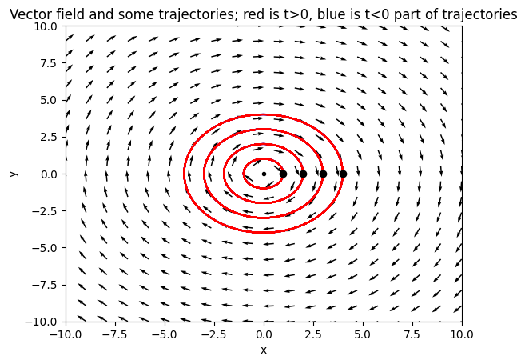

$\displaystyle \dfrac{d}{dt}\left[ \begin{array}{c} x(t) \\ y(t) \end{array} \right] = \left[ \begin{array}{cc} 0 & 4 \\ -4 & 0 \end{array} \right] \left[ \begin{array}{c} x(t) \\ y(t) \end{array} \right]$

```
General solution:
```

$\displaystyle x{\left(t \right)} = C_{1} \sin{\left(4 t \right)} + C_{2} \cos{\left(4 t \right)}$

$\displaystyle y{\left(t \right)} = C_{1} \cos{\left(4 t \right)} - C_{2} \sin{\left(4 t \right)}$

```python
#@title 3.12(i)


from IPython.display import display, Math
import matplotlib.pyplot as plt
import numpy as np
from scipy.integrate import solve_ivp
from sympy import Function, dsolve, Eq, diff, symbols, latex, simplify, expand


#
# Define the matrix entries
#
a=0
b=4
c=-4
d=0
#
# Enter the list of initial conditions to plot
#
ics = [[1,0], [2,0], [3,0], [4,0]]




# Define symbols for sympy
t = symbols('t')
x = Function('x')
y = Function('y')

def odesys(a,b,c,d):
  return [Eq (diff(x(t),t) , a*x(t) + b*y(t) ), Eq (diff(y(t),t) , c*x(t) + d*y(t) )]



# Define the ODE system for scipy to numerically integrate
def DE(t, z, a,b,c,d):
  x,y=z
  dx = a*x + b*y   #Here is where you input f(x,y) for the DE dx/dt = f(x,y)
  dy = c*x + d*y   #Here is where you input g(x,y) for the DE dy/dt = g(x,y)
  return [dx, dy]


# Define the solving/plotting function
def phase_plot(ics, tmax):
  plt.figure()
  # Define window from scale slider choice
  sc=10
  xmin = -sc
  xmax = sc
  ymin = -sc
  ymax = sc
  # Create a grid of points
  tgrid=np.linspace(0,tmax,1000)
  xgrid = np.linspace(xmin, xmax, 20)
  ygrid = np.linspace(ymin, ymax, 20)
  X, Y = np.meshgrid(xgrid, ygrid)
  # Calculate the vector field at each point, normalize to length 1
  U,V = DE(0,(X, Y), a,b,c,d)
  U,V = (U/np.sqrt(U**2+V**2), V/np.sqrt(U**2+V**2))

  #Solve numerically using solver from scipy
  for point in ics:
      [x_0, y_0] = point
      sol = solve_ivp(DE, (0,tmax), (x_0,y_0), args=(a,b,c,d), dense_output = 'true')
      sol2 = solve_ivp(DE, (0, -tmax), (x_0,y_0), args=(a,b,c,d), dense_output = 'true')
      xsol2=sol2.sol(-tgrid)[0]
      ysol2=sol2.sol(-tgrid)[1]
      plt.plot(xsol2,ysol2, color='blue')
      xsol=sol.sol(tgrid)[0]
      ysol=sol.sol(tgrid)[1]
      plt.plot(xsol,ysol, color='red')
      plt.plot(x_0, y_0, 'o', color='black')
  plt.plot(0,0,'.', color='black')
  #Plot slope field
  plt.quiver(X, Y, U, V,angles='xy')
  #Plot numerical solution satisfying x(0) = x_0, y(0) = y_0
  #Set up plot
  plt.xlabel('x')
  plt.ylabel('y')
  plt.xlim(xmin, xmax)
  plt.ylim(ymin, ymax)
  plt.title('Vector field and some trajectories; red is t>0, blue is t<0 part of trajectories')
  plt.show()
  display(Math(r'\dfrac{d}{dt}\left[ \begin{array}{c} x(t) \\ y(t) \end{array} \right] = \left[ \begin{array}{cc} %s & %s \\ %s & %s \end{array} \right] \left[ \begin{array}{c} x(t) \\ y(t) \end{array} \right]' % (a, b, c, d) ))
  print()
  print()
  print('General solution:')
  solution = dsolve(odesys(a,b,c,d))
  for comp in solution:
    display(Math(latex(expand(simplify(comp,rational=True)))))
    print()

phase_plot(ics, 10)
```

# (ii)

For $$\mathbf{A} = \left[ \begin{array}{cc} 0 & 4 \\ -1 & 4 \end{array} \right], $$ we have $$0 = \lambda^2 - \operatorname{tr}(\mathbf{A})\lambda + \operatorname{det}(\mathbf{A}) = \lambda^2 - (4)\lambda + (4)=\lambda^2 -4\lambda + 4 = (\lambda-2)^2.$$

We have a repeated positive eigenvalue, and so the origin is a $\boxed{\text{unstable node}}$.

It's a little trickier to analyze given the algebraic factor of $t$, but "nodes with repeated eigenvalues and only one linearly independent eigenvector" look somewhat similar to the $\lambda_1 < \lambda_2 < 0$ or $\lambda_2 > \lambda_1 > 0$ nodes, except there is only one straight line trajectory, and all solutions become tangent to that single direction as $t \to \pm \infty$.

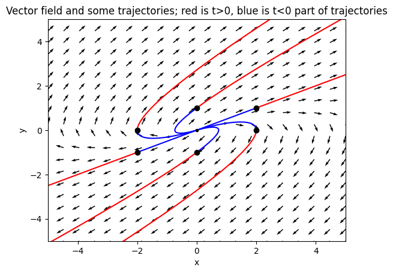

$\displaystyle \dfrac{d}{dt}\left[ \begin{array}{c} x(t) \\ y(t) \end{array} \right] = \left[ \begin{array}{cc} 0 & 4 \\ -1 & 4 \end{array} \right] \left[ \begin{array}{c} x(t) \\ y(t) \end{array} \right]$

```
General solution:
```

$\displaystyle x{\left(t \right)} = - 2 C_{1} e^{2 t} - 2 C_{2} t e^{2 t} + C_{2} e^{2 t}$

$\displaystyle y{\left(t \right)} = - C_{1} e^{2 t} - C_{2} t e^{2 t}$

```python
#@title 3.12(ii)


from IPython.display import display, Math
import matplotlib.pyplot as plt
import numpy as np
from scipy.integrate import solve_ivp
from sympy import Function, dsolve, Eq, diff, symbols, latex, simplify, expand


#
# Define the matrix entries
#
a=0
b=4
c=-1
d=4
#
# Enter the list of initial conditions to plot
#
ics = [[2,1], [-2,-1], [0,1], [0,-1], [-2, 0], [2,0]]




# Define symbols for sympy
t = symbols('t')
x = Function('x')
y = Function('y')

def odesys(a,b,c,d):
  return [Eq (diff(x(t),t) , a*x(t) + b*y(t) ), Eq (diff(y(t),t) , c*x(t) + d*y(t) )]



# Define the ODE system for scipy to numerically integrate
def DE(t, z, a,b,c,d):
  x,y=z
  dx = a*x + b*y   #Here is where you input f(x,y) for the DE dx/dt = f(x,y)
  dy = c*x + d*y   #Here is where you input g(x,y) for the DE dy/dt = g(x,y)
  return [dx, dy]


# Define the solving/plotting function
def phase_plot(ics, tmax):
  plt.figure()
  # Define window from scale slider choice
  sc=5
  xmin = -sc
  xmax = sc
  ymin = -sc
  ymax = sc
  # Create a grid of points
  tgrid=np.linspace(0,tmax,1000)
  xgrid = np.linspace(xmin, xmax, 20)
  ygrid = np.linspace(ymin, ymax, 20)
  X, Y = np.meshgrid(xgrid, ygrid)
  # Calculate the vector field at each point, normalize to length 1
  U,V = DE(0,(X, Y), a,b,c,d)
  U,V = (U/np.sqrt(U**2+V**2), V/np.sqrt(U**2+V**2))

  #Solve numerically using solver from scipy
  for point in ics:
      [x_0, y_0] = point
      sol = solve_ivp(DE, (0,tmax), (x_0,y_0), args=(a,b,c,d), dense_output = 'true')
      sol2 = solve_ivp(DE, (0, -tmax), (x_0,y_0), args=(a,b,c,d), dense_output = 'true')
      xsol=sol.sol(tgrid)[0]
      ysol=sol.sol(tgrid)[1]
      plt.plot(xsol,ysol, color='red')
      xsol2=sol2.sol(-tgrid)[0]
      ysol2=sol2.sol(-tgrid)[1]
      plt.plot(xsol2,ysol2, color='blue')
      plt.plot(x_0, y_0, 'o', color='black')
  plt.plot(0,0,'.', color='black')
  #Plot slope field
  plt.quiver(X, Y, U, V,angles='xy')
  #Plot numerical solution satisfying x(0) = x_0, y(0) = y_0
  #Set up plot
  plt.xlabel('x')
  plt.ylabel('y')
  plt.xlim(xmin, xmax)
  plt.ylim(ymin, ymax)
  plt.title('Vector field and some trajectories; red is t>0, blue is t<0 part of trajectories')
  plt.show()
  display(Math(r'\dfrac{d}{dt}\left[ \begin{array}{c} x(t) \\ y(t) \end{array} \right] = \left[ \begin{array}{cc} %s & %s \\ %s & %s \end{array} \right] \left[ \begin{array}{c} x(t) \\ y(t) \end{array} \right]' % (a, b, c, d) ))
  print()
  print()
  print('General solution:')
  solution = dsolve(odesys(a,b,c,d))
  for comp in solution:
    display(Math(latex(expand(simplify(comp,rational=True)))))
    print()

phase_plot(ics, 10)
```

# (iii)

For $$\mathbf{A} = \left[ \begin{array}{cc} -8 & 10 \\ -4 & 4 \end{array} \right], $$ we have $$0 = \lambda^2 - \operatorname{tr}(\mathbf{A})\lambda + \operatorname{det}(\mathbf{A}) = \lambda^2 - (-4)\lambda + (8)=\lambda^2 + 4 \lambda+8 = (\lambda + 2)^2 + 4.$$

As there are no real eigenvectors, there are no straight line trajectories. Checking for example

$$ \mathbf{A} \left[ \begin{array}{c} 1 \\ 0 \end{array}\right] = \left[ \begin{array}{c} -8 \\ -4 \end{array}\right]\qquad \text{and} \qquad \mathbf{A} \left[ \begin{array}{c} 0 \\ 1 \end{array}\right] = \left[ \begin{array}{c} 10 \\ 4 \end{array}\right]$$

we can conclude the trajectories are traced out clockwise with respect to the origin.

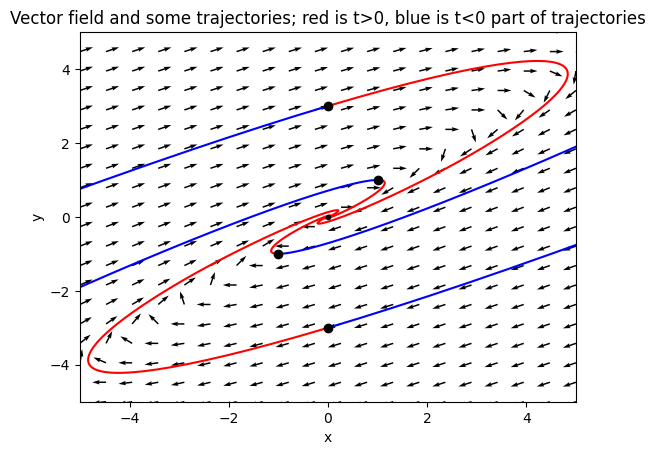

$\displaystyle \dfrac{d}{dt}\left[ \begin{array}{c} x(t) \\ y(t) \end{array} \right] = \left[ \begin{array}{cc} -8 & 10 \\ -4 & 4 \end{array} \right] \left[ \begin{array}{c} x(t) \\ y(t) \end{array} \right]$

```
General solution:
```

$\displaystyle x{\left(t \right)} = - \frac{3 C_{1} e^{- 2 t} \sin{\left(2 t \right)}}{2} + \frac{C_{1} e^{- 2 t} \cos{\left(2 t \right)}}{2} + \frac{C_{2} e^{- 2 t} \sin{\left(2 t \right)}}{2} + \frac{3 C_{2} e^{- 2 t} \cos{\left(2 t \right)}}{2}$

$\displaystyle y{\left(t \right)} = - C_{1} e^{- 2 t} \sin{\left(2 t \right)} + C_{2} e^{- 2 t} \cos{\left(2 t \right)}$

```python
#@title 3.12(iii)


from IPython.display import display, Math
import matplotlib.pyplot as plt
import numpy as np
from scipy.integrate import solve_ivp
from sympy import Function, dsolve, Eq, diff, symbols, latex, simplify, expand


#
# Define the matrix entries
#
a=-8
b=10
c=-4
d=4
#
# Enter the list of initial conditions to plot
#
ics = [[1,1], [-1,-1], [0,3], [0,-3]]




# Define symbols for sympy
t = symbols('t')
x = Function('x')
y = Function('y')

def odesys(a,b,c,d):
  return [Eq (diff(x(t),t) , a*x(t) + b*y(t) ), Eq (diff(y(t),t) , c*x(t) + d*y(t) )]



# Define the ODE system for scipy to numerically integrate
def DE(t, z, a,b,c,d):
  x,y=z
  dx = a*x + b*y   #Here is where you input f(x,y) for the DE dx/dt = f(x,y)
  dy = c*x + d*y   #Here is where you input g(x,y) for the DE dy/dt = g(x,y)
  return [dx, dy]


# Define the solving/plotting function
def phase_plot(ics, tmax):
  plt.figure()
  # Define window from scale slider choice
  sc=5
  xmin = -sc
  xmax = sc
  ymin = -sc
  ymax = sc
  # Create a grid of points
  tgrid=np.linspace(0,tmax,1000)
  xgrid = np.linspace(xmin, xmax, 20)
  ygrid = np.linspace(ymin, ymax, 20)
  X, Y = np.meshgrid(xgrid, ygrid)
  # Calculate the vector field at each point, normalize to length 1
  U,V = DE(0,(X, Y), a,b,c,d)
  U,V = (U/np.sqrt(U**2+V**2), V/np.sqrt(U**2+V**2))

  #Solve numerically using solver from scipy
  for point in ics:
      [x_0, y_0] = point
      sol = solve_ivp(DE, (0,tmax), (x_0,y_0), args=(a,b,c,d), dense_output = 'true')
      sol2 = solve_ivp(DE, (0, -tmax), (x_0,y_0), args=(a,b,c,d), dense_output = 'true')
      xsol=sol.sol(tgrid)[0]
      ysol=sol.sol(tgrid)[1]
      plt.plot(xsol,ysol, color='red')
      xsol2=sol2.sol(-tgrid)[0]
      ysol2=sol2.sol(-tgrid)[1]
      plt.plot(xsol2,ysol2, color='blue')
      plt.plot(x_0, y_0, 'o', color='black')
  plt.plot(0,0,'.', color='black')
  #Plot slope field
  plt.quiver(X, Y, U, V,angles='xy')
  #Plot numerical solution satisfying x(0) = x_0, y(0) = y_0
  #Set up plot
  plt.xlabel('x')
  plt.ylabel('y')
  plt.xlim(xmin, xmax)
  plt.ylim(ymin, ymax)
  plt.title('Vector field and some trajectories; red is t>0, blue is t<0 part of trajectories')
  plt.show()
  display(Math(r'\dfrac{d}{dt}\left[ \begin{array}{c} x(t) \\ y(t) \end{array} \right] = \left[ \begin{array}{cc} %s & %s \\ %s & %s \end{array} \right] \left[ \begin{array}{c} x(t) \\ y(t) \end{array} \right]' % (a, b, c, d) ))
  print()
  print()
  print('General solution:')
  solution = dsolve(odesys(a,b,c,d))
  for comp in solution:
    display(Math(latex(expand(simplify(comp,rational=True)))))
    print()

phase_plot(ics, 10)
```

# (iv)

For $$\mathbf{A} = \left[ \begin{array}{cc} -1 & -5 \\ 2 & 5 \end{array} \right], $$ we have $$0 = \lambda^2 - \operatorname{tr}(\mathbf{A})\lambda + \operatorname{det}(\mathbf{A}) = \lambda^2 - (4)\lambda + (5)=\lambda^2 - 4 \lambda+5 = (\lambda - 2)^2 + 1.$$

As there are no real eigenvectors, there are no straight line trajectories. Checking for example

$$ \mathbf{A} \left[ \begin{array}{c} 1 \\ 0 \end{array}\right] = \left[ \begin{array}{c} -1 \\ 2 \end{array}\right]\qquad \text{and} \qquad \mathbf{A} \left[ \begin{array}{c} 0 \\ 1 \end{array}\right] = \left[ \begin{array}{c} -5 \\ 5 \end{array}\right]$$

we can conclude the trajectories are traced out counterclockwise with respect to the origin. The spiral is a little hard to see --- every time $t$ increases by $2\pi,$ each of $x,y$ increase by a factor of $e^{2(2\pi)} = e^{4\pi}$, which is quite large.

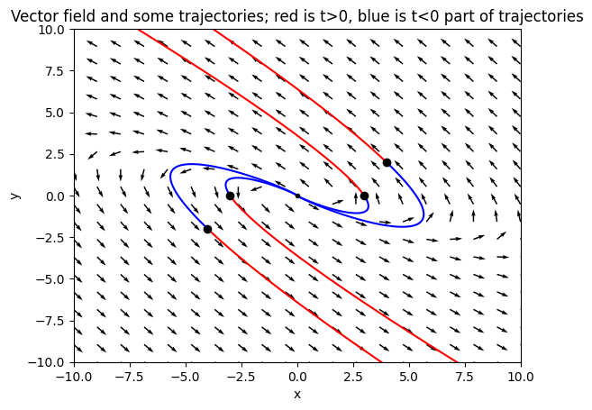

$\displaystyle \dfrac{d}{dt}\left[ \begin{array}{c} x(t) \\ y(t) \end{array} \right] = \left[ \begin{array}{cc} -1 & -5 \\ 2 & 5 \end{array} \right] \left[ \begin{array}{c} x(t) \\ y(t) \end{array} \right]$

```
General solution:
```

$\displaystyle x{\left(t \right)} = - \frac{C_{1} e^{2 t} \sin{\left(t \right)}}{2} - \frac{3 C_{1} e^{2 t} \cos{\left(t \right)}}{2} + \frac{3 C_{2} e^{2 t} \sin{\left(t \right)}}{2} - \frac{C_{2} e^{2 t} \cos{\left(t \right)}}{2}$

$\displaystyle y{\left(t \right)} = C_{1} e^{2 t} \cos{\left(t \right)} - C_{2} e^{2 t} \sin{\left(t \right)}$

```python
#@title 3.12(iv)


from IPython.display import display, Math
import matplotlib.pyplot as plt
import numpy as np
from scipy.integrate import solve_ivp
from sympy import Function, dsolve, Eq, diff, symbols, latex, simplify, expand


#
# Define the matrix entries
#
a=-1
b=-5
c=2
d=5
#
# Enter the list of initial conditions to plot
#
ics = [[3, 0], [-4, -2], [4, 2], [-3, 0]]




# Define symbols for sympy
t = symbols('t')
x = Function('x')
y = Function('y')

def odesys(a,b,c,d):
  return [Eq (diff(x(t),t) , a*x(t) + b*y(t) ), Eq (diff(y(t),t) , c*x(t) + d*y(t) )]



# Define the ODE system for scipy to numerically integrate
def DE(t, z, a,b,c,d):
  x,y=z
  dx = a*x + b*y   #Here is where you input f(x,y) for the DE dx/dt = f(x,y)
  dy = c*x + d*y   #Here is where you input g(x,y) for the DE dy/dt = g(x,y)
  return [dx, dy]


# Define the solving/plotting function
def phase_plot(ics, tmax):
  plt.figure()
  # Define window from scale slider choice
  sc=10
  xmin = -sc
  xmax = sc
  ymin = -sc
  ymax = sc
  # Create a grid of points
  tgrid=np.linspace(0,tmax,1000)
  xgrid = np.linspace(xmin, xmax, 20)
  ygrid = np.linspace(ymin, ymax, 20)
  X, Y = np.meshgrid(xgrid, ygrid)
  # Calculate the vector field at each point, normalize to length 1
  U,V = DE(0,(X, Y), a,b,c,d)
  U,V = (U/np.sqrt(U**2+V**2), V/np.sqrt(U**2+V**2))

  #Solve numerically using solver from scipy
  for point in ics:
      [x_0, y_0] = point
      sol = solve_ivp(DE, (0,tmax), (x_0,y_0), args=(a,b,c,d), dense_output = 'true')
      sol2 = solve_ivp(DE, (0, -tmax), (x_0,y_0), args=(a,b,c,d), dense_output = 'true')
      xsol=sol.sol(tgrid)[0]
      ysol=sol.sol(tgrid)[1]
      plt.plot(xsol,ysol, color='red')
      xsol2=sol2.sol(-tgrid)[0]
      ysol2=sol2.sol(-tgrid)[1]
      plt.plot(xsol2,ysol2, color='blue')
      plt.plot(x_0, y_0, 'o', color='black')
  plt.plot(0,0,'.', color='black')
  #Plot slope field
  plt.quiver(X, Y, U, V,angles='xy')
  #Plot numerical solution satisfying x(0) = x_0, y(0) = y_0
  #Set up plot
  plt.xlabel('x')
  plt.ylabel('y')
  plt.xlim(xmin, xmax)
  plt.ylim(ymin, ymax)
  plt.title('Vector field and some trajectories; red is t>0, blue is t<0 part of trajectories')
  plt.show()
  display(Math(r'\dfrac{d}{dt}\left[ \begin{array}{c} x(t) \\ y(t) \end{array} \right] = \left[ \begin{array}{cc} %s & %s \\ %s & %s \end{array} \right] \left[ \begin{array}{c} x(t) \\ y(t) \end{array} \right]' % (a, b, c, d) ))
  print()
  print()
  print('General solution:')
  solution = dsolve(odesys(a,b,c,d))
  for comp in solution:
    display(Math(latex(expand(simplify(comp,rational=True)))))
    print()

phase_plot(ics, 10)
```

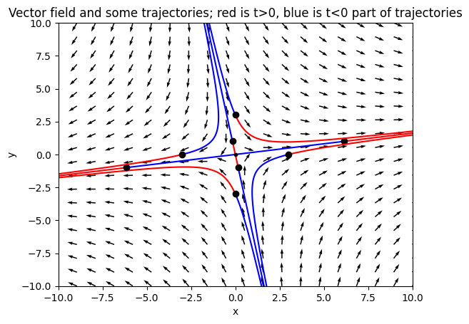

$\displaystyle \dfrac{d}{dt}\left[ \begin{array}{c} x(t) \\ y(t) \end{array} \right] = \left[ \begin{array}{cc} 3 & 1 \\ 1 & -3 \end{array} \right] \left[ \begin{array}{c} x(t) \\ y(t) \end{array} \right]$

```
General solution:
```

$\displaystyle x{\left(t \right)} = - \sqrt{10} C_{1} e^{- \sqrt{10} t} + 3 C_{1} e^{- \sqrt{10} t} + 3 C_{2} e^{\sqrt{10} t} + \sqrt{10} C_{2} e^{\sqrt{10} t}$

$\displaystyle y{\left(t \right)} = C_{1} e^{- \sqrt{10} t} + C_{2} e^{\sqrt{10} t}$

```python
#@title 32.2


from IPython.display import display, Math
import matplotlib.pyplot as plt
import numpy as np
from scipy.integrate import solve_ivp
from sympy import Function, dsolve, Eq, diff, symbols, latex, simplify, expand


#
# Define the matrix entries
#
a=3
b=1
c=1
d=-3
#
# Enter the list of initial conditions to plot
#
ics = [[0,-3], [3-np.sqrt(10),1],[-3+np.sqrt(10),-1], [3+np.sqrt(10),1],[-(3+np.sqrt(10)),-1], [0,3], [3,0],[-3,0]]




# Define symbols for sympy
t = symbols('t')
x = Function('x')
y = Function('y')

def odesys(a,b,c,d):
  return [Eq (diff(x(t),t) , a*x(t) + b*y(t) ), Eq (diff(y(t),t) , c*x(t) + d*y(t) )]



# Define the ODE system for scipy to numerically integrate
def DE(t, z, a,b,c,d):
  x,y=z
  dx = a*x + b*y   #Here is where you input f(x,y) for the DE dx/dt = f(x,y)
  dy = c*x + d*y   #Here is where you input g(x,y) for the DE dy/dt = g(x,y)
  return [dx, dy]


# Define the solving/plotting function
def phase_plot(ics, tmax):
  plt.figure()
  # Define window from scale slider choice
  sc=10
  xmin = -sc
  xmax = sc
  ymin = -sc
  ymax = sc
  # Create a grid of points
  tgrid=np.linspace(0,tmax,1000)
  xgrid = np.linspace(xmin, xmax, 20)
  ygrid = np.linspace(ymin, ymax, 20)
  X, Y = np.meshgrid(xgrid, ygrid)
  # Calculate the vector field at each point, normalize to length 1
  U,V = DE(0,(X, Y), a,b,c,d)
  U,V = (U/np.sqrt(U**2+V**2), V/np.sqrt(U**2+V**2))

  #Solve numerically using solver from scipy
  for point in ics:
      [x_0, y_0] = point
      sol = solve_ivp(DE, (0,tmax), (x_0,y_0), args=(a,b,c,d), dense_output = 'true')
      sol2 = solve_ivp(DE, (0, -tmax), (x_0,y_0), args=(a,b,c,d), dense_output = 'true')
      xsol=sol.sol(tgrid)[0]
      ysol=sol.sol(tgrid)[1]
      plt.plot(xsol,ysol, color='red')
      xsol2=sol2.sol(-tgrid)[0]
      ysol2=sol2.sol(-tgrid)[1]
      plt.plot(xsol2,ysol2, color='blue')
      plt.plot(x_0, y_0, 'o', color='black')
  plt.plot(0,0,'.', color='black')
  #Plot slope field
  plt.quiver(X, Y, U, V,angles='xy')
  #Plot numerical solution satisfying x(0) = x_0, y(0) = y_0
  #Set up plot
  plt.xlabel('x')
  plt.ylabel('y')
  plt.xlim(xmin, xmax)
  plt.ylim(ymin, ymax)
  plt.title('Vector field and some trajectories; red is t>0, blue is t<0 part of trajectories')
  plt.show()
  display(Math(r'\dfrac{d}{dt}\left[ \begin{array}{c} x(t) \\ y(t) \end{array} \right] = \left[ \begin{array}{cc} %s & %s \\ %s & %s \end{array} \right] \left[ \begin{array}{c} x(t) \\ y(t) \end{array} \right]' % (a, b, c, d) ))
  print()
  print()
  print('General solution:')
  solution = dsolve(odesys(a,b,c,d))
  for comp in solution:
    display(Math(latex(expand(simplify(comp,rational=True)))))
    print()

phase_plot(ics, 10)
```

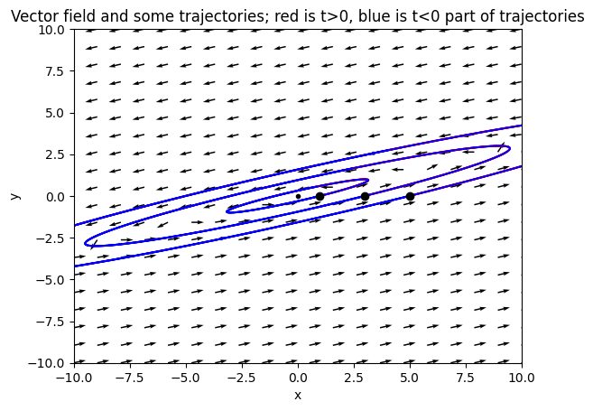

$\displaystyle \dfrac{d}{dt}\left[ \begin{array}{c} x(t) \\ y(t) \end{array} \right] = \left[ \begin{array}{cc} 3 & -10 \\ 1 & -3 \end{array} \right] \left[ \begin{array}{c} x(t) \\ y(t) \end{array} \right]$

```
General solution:
```

$\displaystyle x{\left(t \right)} = - 3 C_{1} \sin{\left(t \right)} - C_{1} \cos{\left(t \right)} - C_{2} \sin{\left(t \right)} + 3 C_{2} \cos{\left(t \right)}$

$\displaystyle y{\left(t \right)} = - C_{1} \sin{\left(t \right)} + C_{2} \cos{\left(t \right)}$

```python
#@title 32.2


from IPython.display import display, Math
import matplotlib.pyplot as plt
import numpy as np
from scipy.integrate import solve_ivp
from sympy import Function, dsolve, Eq, diff, symbols, latex, simplify, expand


#
# Define the matrix entries
#
a=3
b=-10
c=1
d=-3
#
# Enter the list of initial conditions to plot
#
ics = [[1, 0], [3,0],[5,0]]




# Define symbols for sympy
t = symbols('t')
x = Function('x')
y = Function('y')

def odesys(a,b,c,d):
  return [Eq (diff(x(t),t) , a*x(t) + b*y(t) ), Eq (diff(y(t),t) , c*x(t) + d*y(t) )]



# Define the ODE system for scipy to numerically integrate
def DE(t, z, a,b,c,d):
  x,y=z
  dx = a*x + b*y   #Here is where you input f(x,y) for the DE dx/dt = f(x,y)
  dy = c*x + d*y   #Here is where you input g(x,y) for the DE dy/dt = g(x,y)
  return [dx, dy]


# Define the solving/plotting function
def phase_plot(ics, tmax):
  plt.figure()
  # Define window from scale slider choice
  sc=10
  xmin = -sc
  xmax = sc
  ymin = -sc
  ymax = sc
  # Create a grid of points
  tgrid=np.linspace(0,tmax,1000)
  xgrid = np.linspace(xmin, xmax, 20)
  ygrid = np.linspace(ymin, ymax, 20)
  X, Y = np.meshgrid(xgrid, ygrid)
  # Calculate the vector field at each point, normalize to length 1
  U,V = DE(0,(X, Y), a,b,c,d)
  U,V = (U/np.sqrt(U**2+V**2), V/np.sqrt(U**2+V**2))

  #Solve numerically using solver from scipy
  for point in ics:
      [x_0, y_0] = point
      sol = solve_ivp(DE, (0,tmax), (x_0,y_0), args=(a,b,c,d), dense_output = 'true')
      sol2 = solve_ivp(DE, (0, -tmax), (x_0,y_0), args=(a,b,c,d), dense_output = 'true')
      xsol=sol.sol(tgrid)[0]
      ysol=sol.sol(tgrid)[1]
      plt.plot(xsol,ysol, color='red')
      xsol2=sol2.sol(-tgrid)[0]
      ysol2=sol2.sol(-tgrid)[1]
      plt.plot(xsol2,ysol2, color='blue')
      plt.plot(x_0, y_0, 'o', color='black')
  plt.plot(0,0,'.', color='black')
  #Plot slope field
  plt.quiver(X, Y, U, V,angles='xy')
  #Plot numerical solution satisfying x(0) = x_0, y(0) = y_0
  #Set up plot
  plt.xlabel('x')
  plt.ylabel('y')
  plt.xlim(xmin, xmax)
  plt.ylim(ymin, ymax)
  plt.title('Vector field and some trajectories; red is t>0, blue is t<0 part of trajectories')
  plt.show()
  display(Math(r'\dfrac{d}{dt}\left[ \begin{array}{c} x(t) \\ y(t) \end{array} \right] = \left[ \begin{array}{cc} %s & %s \\ %s & %s \end{array} \right] \left[ \begin{array}{c} x(t) \\ y(t) \end{array} \right]' % (a, b, c, d) ))
  print()
  print()
  print('General solution:')
  solution = dsolve(odesys(a,b,c,d))
  for comp in solution:
    display(Math(latex(expand(simplify(comp,rational=True)))))
    print()

phase_plot(ics, 10)
```